# R review

Kevinhuang

2020/5/6

R的基礎數學運算

> 加減乘除、次方、取餘數、取商數

```r
a<-20
b<-2
a+b
a-b
a*b
a/b
a^b
a%%b # 餘數
a%/%b # 商數
```

> 取log、指數、絕對值、開根號

```r
log(a)
log(b,base=10)
exp(b)
abs(b-a)
sqrt(b)
```

> 特殊值(e跟$pi$)、約略值(四捨五入、無條件進位、無條件捨去)

```r
#特殊值
exp(1)
pi
#約略值
c<-49883.2233
round(c,digits=2) #可以決定進位到哪位
signif(c) #四捨五入
ceiling(c) #無條件進位
floor(c) #無條件捨去
```

以「常態分布的機率密度函數」為例，常態分布的pdf為
$$f(x)=\frac{1}{\sqrt{2\pi}\sigma}e^{-\frac{(x-\mu)^2}{2\sigma^2}} ,-\infty<x<\infty$$
當$X\sim N(0,1)$的標準常態下，則$x=0$時可得 pdf = 0.398942。

```r
mu<-0
sigma<-1
x<-0
round(exp(1)^((-((x-mu)/sigma)^2)/2)*(1/sqrt(2*pi)*sigma),6)
dnorm(0,0,1)
```

R的資料格式

> 資料型態 ：Doubles(浮點數)、Integer(整數)、character(文字)、logical(邏輯T/F)、complex(複數)、factor(因子)

```r
a<-c(1,2,3)
b<-c(1L,2L,3L)
c<-c('how','are','you')
d<-(4>3)&(5==3)
e<-c(1+1i,1+2i,1+3i)
f<-factor(c,labels = c('one','two','three'))#按照第一個字母排序 #可用label調整效果的名稱
levels(f)

#轉換資料類型
as.integer(a)
as.character(b)
as.double(a)

#判斷資料類型
is.character(c)
is.integer(b)
is.numeric(a)

#檢視是什麼樣的資料
typeof(a)
```

> 資料結構 ：vector、matrix、list、dataframe

vector(適合數值、文字的資料)

以「c()且用逗號分隔」的方式存取資料。

- 數值向量

```r
n1<-c(1:10)
n2<-seq(1, 5, by = 0.5) #每固定間距來產生新資料
n3<-seq(1, 10, length.out = 4) #產生一個等距的新資料
n4<-rep(3, 12)
n5<-rep(c(2,20,12,6,3), 2)

#向量合併
c(n1,n3)

#取向量的值(註：第一個值為1,而非為0)
n1[1]
n2[2:5]
n2[c(2:5)]
n3[-c(2:4)]#由負號取剩下的位置


#改變向量的值
n1[2]<-5
n2[2:4]<-rep(3,3)
n3[4]<-'h'  #特別注意：當把值改成字串，其他數值也會變成字串

#整理向量的值
sort(n5) #直接排序
order(n5) #回傳排序的位置
n5[order(n5)]
sort(n5,decreasing = T)#改為由大到小
order(n5,decreasing = T)
n5[order(n5,decreasing = T)]
which(n1==5)#找特定值的位置
grep(5,n1)

#向量相乘
n1+1
n1*3
n1*c(2,3) #以c(2,3)複製符合n1的長度

#向量資訊
length(n1) #長度
sum(n1) #總合
unique(n5) #獨特值
table(n5) #每個獨特值的個數
```

- 字串向量

```r
TEXT1 <- "You're so great !"
TEXT2 <- c('yellow','red','white','orange')

#切割文字
strsplit(TEXT1, " ") #以「空白」來切割字串

#英文大小寫
toupper(TEXT1)
tolower(TEXT1)

#文字搜尋跟更正
substr(TEXT1,1,4) #取部分字串
grep("w", TEXT2) #取得有特定字的位置
gsub("o","0",TEXT1) #修改文字

#將字串連起來
paste(TEXT2,'++') #向量內的每個值加上「++」
paste(TEXT2,collapse =' ~ ') # 以「~」來連接向量內的每個值
cat(TEXT1,TEXT2) #跟paste比較，沒有「引號」

#字串的順序(依照英文字母)
sort(TEXT2)
```

matrix (適合處理全部都是數值的資料)

以「n行、m列」的結構來儲存資料。

```r
A <- matrix(c(60,80,70,79),2,2)
B <- matrix(c(1:4),2,2,byrow = T) #可以調整放入資料的方式，以「row或column」依序存入
C <- rbind(c(4,6),c(8,2)) #以row的方式來合併多筆資料
D <- cbind(c(9,10,74),c(22,40,66)) #以column的方式來合併多筆資料

#行的名稱、列的名稱
colnames(A)<-c('math','chinese')
rownames(A)<-c('marry','john')

#查看矩陣的資訊
dim(D) # row,column
A[2,]#看第二row
A['john',] #也可以用名稱

#修改資料(不適合改成factor,因為不能處理，也不適合字串，只要任一直轉字串，就會整個改變)
A[2,1]<-10000
A[2,]<-c(2,3)

#矩陣的運算
diag(A)
det(A)
A%*%B #內積
t(A)#transpose
solve(A)#得到inverse
eigen(A) #用list存取資料
eigen(A)$values
eigen(A)$vectors
```

list(適合存取不同屬性的資料)

以網狀結構存取不同資料，特色為存取不同類型、長度的資料。

```r
#假設一組學生資料
info<-list(Students=c("kevin","oliver","Emma","Amy"),Year=2014,
                 Score=c(88,50,30,77),School=c("ncku",'NTU'))
#查看list資料
info$Students #所有學生名字
info[3] #得到所有分數
info[[4]][1] #取得ncku

#增加新資料
info$height<-c(177,166,180,160)

#改資料
info$year<-2016
```

dataframe(適合存取外部資料，像是csv、txt)

```r
#會自動將字串資料轉成factor，可以用「stringsAsFactors = FALSE」調整
info<-data.frame(Students=c("kevin","oliver","Emma","Amy"),Year=c(2014,2015,2019,2020),
                 Score=c(88,50,30,77),School=c("ncku",'NTU','NTU','ncku'),stringsAsFactors = FALSE)

#看資料的資訊
head(info,2)
str(info)
View(info)
colnames(info)
summary(info)

#查看以及修改資料
info$Students
info[1,]#跟矩陣一樣
info$Score[2]<-66
info$School<-factor(info$School)
info$age<-c(22,23,24,20)
```

R的迴圈(for/while)、if/else

以例子來說明迴圈與條件：

1. 想像我們以原點（0,0）為原心畫一個半徑為1的圓形，此面積應該是Pi。
2. 畫一個包含圓形完全在正方形內。連接（-1,-1）,(1,-1),(1,1),(-1,1)四個點，會形成一個正方形，假設面積是A。
3. 想像在方形範圍內，隨機發射飛鏢，那麼，掉在圓內的機率是$\pi$/A。
4. 丟一堆飛鏢，估計出 $\pi$/A，乘上A就可以估計出 $\pi$。
5. 我們試著丟10000次看看，求出$\pi$。

```r
count<-0
for (i in 1:10000){
  x<-runif(1,-1,1)
  y<-runif(1,-1,1)
  if(x^2+y^2<1){
    count<-count+1
  }
}
count/10000*(2*2)
```

R的function以及module

> R語言有許多內建的好用module，像是統計工具、apply家族。

以介紹「apply家族」來舉例。 可以得到用迴圈的效果，卻可以節省很多處理時間，適合大筆資料處理

```r
data1<-matrix(1:30,6,5)
#data2為六筆文具價格表
data2<-data.frame(item=c('pen','pencil','ruler','pen','pencil','ruler'),price=c(10,20,30,25,40,30))

#apply >> 針對矩陣的資料類型，可以對每row或column套用特別函數
apply(data1,1,sum) #針對row
apply(data1,2,function(a)sum(a^2)) #針對column

#tapply >> 針對資料的特定column，以另一個column來分類
tapply(data2$price,data2$item,mean) #算每種文具的平均價
```

> 透過「install.packages(‘XXX’)」來安裝新模組，並每次需要該module時，可以用library()來呼叫特定module。

以介紹「magrittr」來舉例。 主要是為了讓複雜的code，可以更清楚表達，不用重新設變數，通常以「%>%」呈現

```r
library(magrittr)
#用data2來示範，算所有文具的平均價格
data2 %>% .[,2] %>% mean #「.」表示上一部的變數

#用iris的資料來做迴歸
iris %<>% lm(Sepal.Length ~ Sepal.Width, data = .)%>%summary #「%<>%」將處理完的變數存回iris變數
```

> 當然，你也可以自己創造屬於自己的工具，此功能為「function」，可以將多個功能合併成一個，或是自己創造一個新方法，達到減少寫重複的code。

建立一個人名名單，對每個人說HI，並最後加上「LOVE&PEACE」

```r
name<-c('kevin','steve','karen')
hello<-function(x){
  for(y in 1:3){
    x[y]<-(paste('Hi~',x[y]))}
  return(c(x,'LOVE&PEACE'))
  }
hello(name)
```

```
## [1] "Hi~ kevin"  "Hi~ steve"  "Hi~ karen"  "LOVE&PEACE"
```

資料讀取示範

```r
titanic<-read.csv('titanic.csv',header = T,stringsAsFactors = F) #讀檔自動把字串改為factor

#查看資料
head(titanic,3)
tail(titanic,3)
str(titanic)
View(titanic)

#處理遺失值
titanic[titanic==""]<-NA #將空字串改成NA
apply(titanic,2,function(x)sum(is.na(x)))#每一column的遺失值
subset(titanic,select = -Cabin)#刪除很多遺失值的column

#選擇想要的column
data_NEW<-subset(titanic,select = -c(Cabin,PassengerId,Ticket))

#取出有完整資料
titanic[complete.cases(data_NEW),]

#取特定範圍的資料(例：年紀大於20)
subset(titanic,Age>20)

#將資料做分組
cut(titanic$Age,3,label=c('年輕','壯年','老人'))
```

R的統計分析

```r
#用titanic來舉例,年齡的平均數、標準差
mean(titanic$Age,na.rm = T)#去除NA值
sd(titanic$Age,na.rm = T)
summary(titanic$Age)

#用ANOVA檢定「男女購買票價是否有差異」>>答案是有
titanic2<-titanic[complete.cases(data_NEW),]
titanic2$Sex<-factor(titanic2$Sex)
find<-lm(titanic2$Fare~titanic2$Sex)
anova(find)

#用t來檢定「男女購買票價是否有差異」>>答案是有
female<-titanic2[titanic2$Sex=='female',]
male<-titanic2[titanic2$Sex=='male',]
t.test(female$Fare,male$Fare)

#算年齡跟票價的線性回歸>>b1效果顯著
summary(lm(titanic2$Fare~titanic2$Age))
```

[output not shown]

R的畫圖

一般繪圖（長條圖、圓餅圖、直方圖、盒鬚圖、散佈圖)

```r
par(3,4)
```

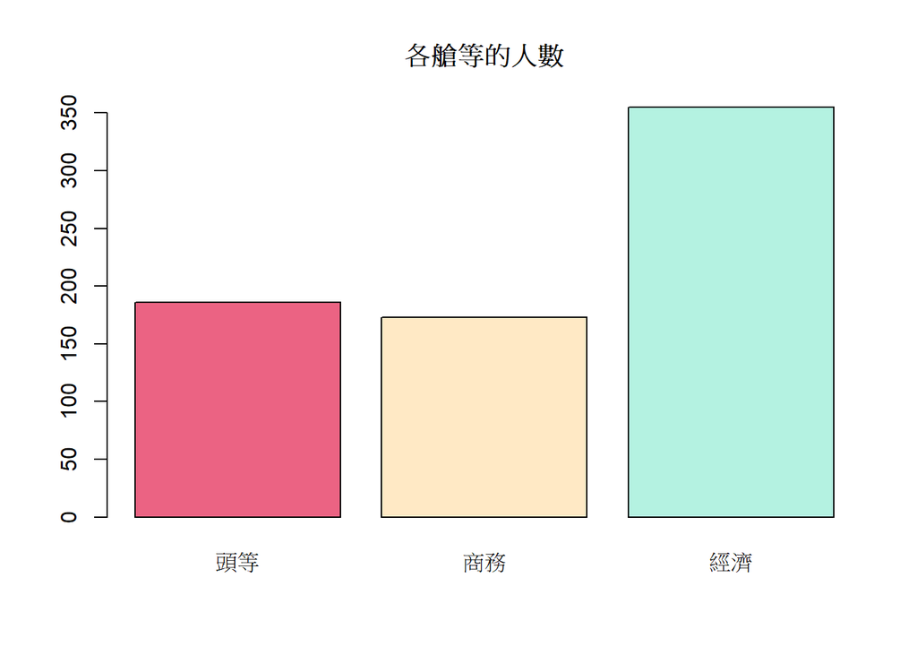

```r
titanic<-read.csv('titanic.csv',header = T,stringsAsFactors = F)
titanic2<-titanic[complete.cases(titanic),]
#barchart、piechart
titanic2$Pclass<-factor(titanic2$Pclass,labels=c('頭等','商務','經濟'))
x<-table(titanic2$Pclass)
names(x)<-c('頭等','商務','經濟')
barplot(x,main='各艙等的人數',col=c('#eb6383','#ffe9c5','#b4f2e1'))
```

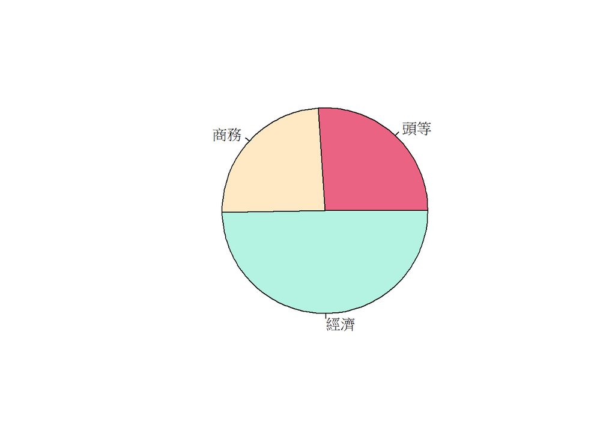

```r
pie(x,col=c('#eb6383','#ffe9c5','#b4f2e1'))
```

[figure not shown]

```r
#Histogram、boxplot
hist(titanic2$Age,col='#ffd3e1',main='性別',ylab='人的年齡',prob=T)
```

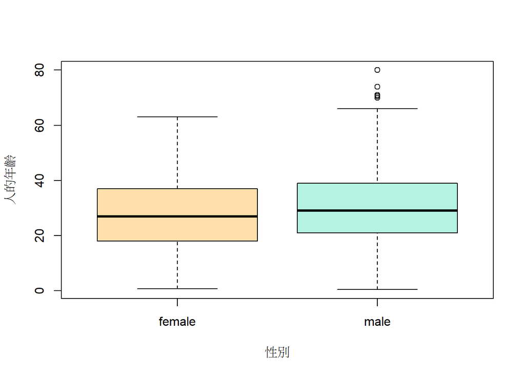

```r
boxplot(titanic2$Age~titanic2$Sex,xlab='性別',ylab='人的年齡',col=c('#ffe0ac','#b4f2e1'))
```

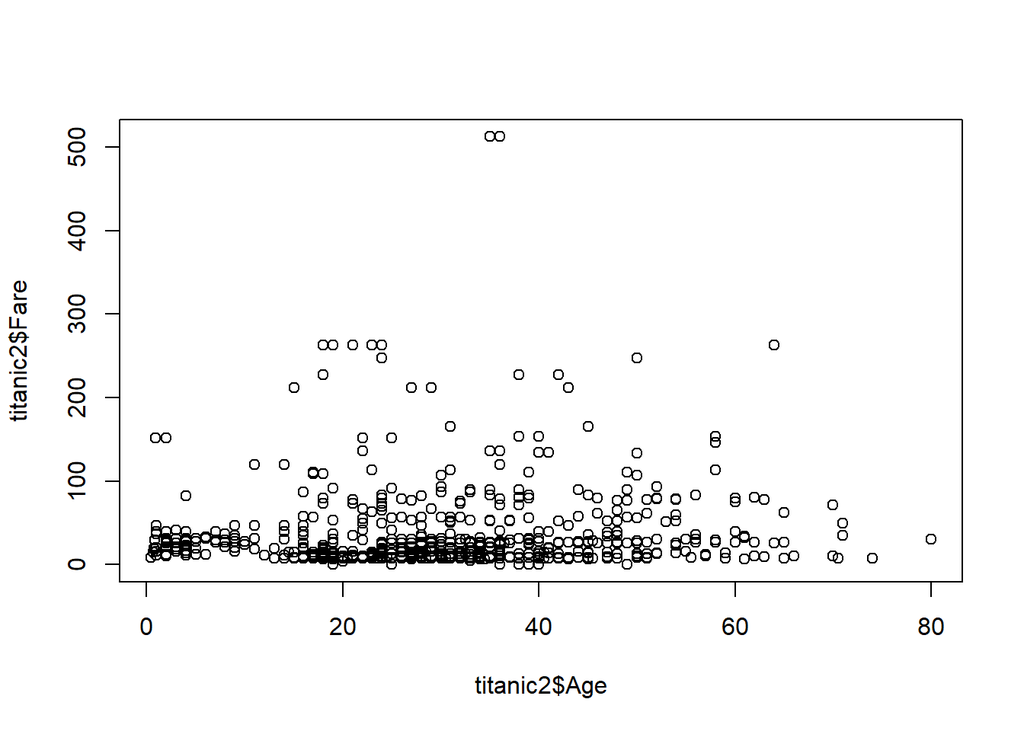

```r
#plot
plot(titanic2$Age,titanic2$Fare)
```

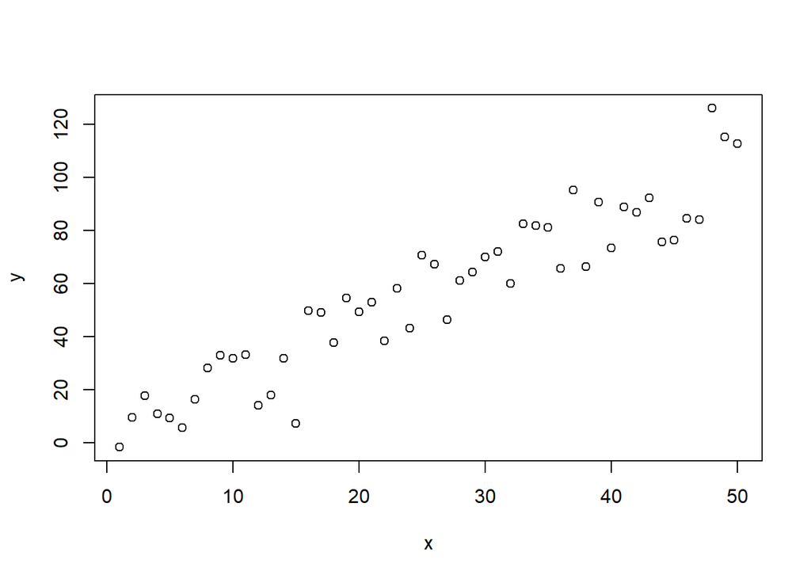

```r
x<-1:50
y<-2*x+5+rnorm(50,0,10)
plot(x,y)
```

特殊繪圖(常態分配圖形、qqplot)

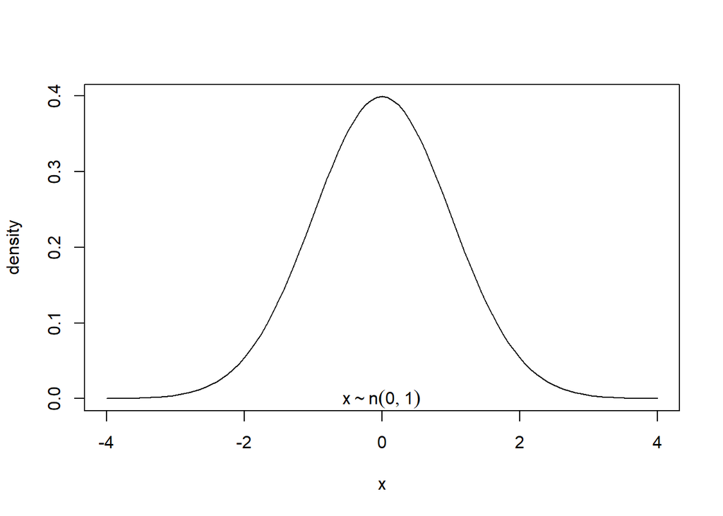

```r
#常態分布圖形
mu<-0
sigma<-1
x<-0
normal<-function(x) exp(1)^((-((x-mu)/sigma)^2)/2)*(1/sqrt(2*pi)*sigma)
curve(normal,from=-4,to=4,ylab='density')
text(0,0,expression(x%~%n(0,1)))
```

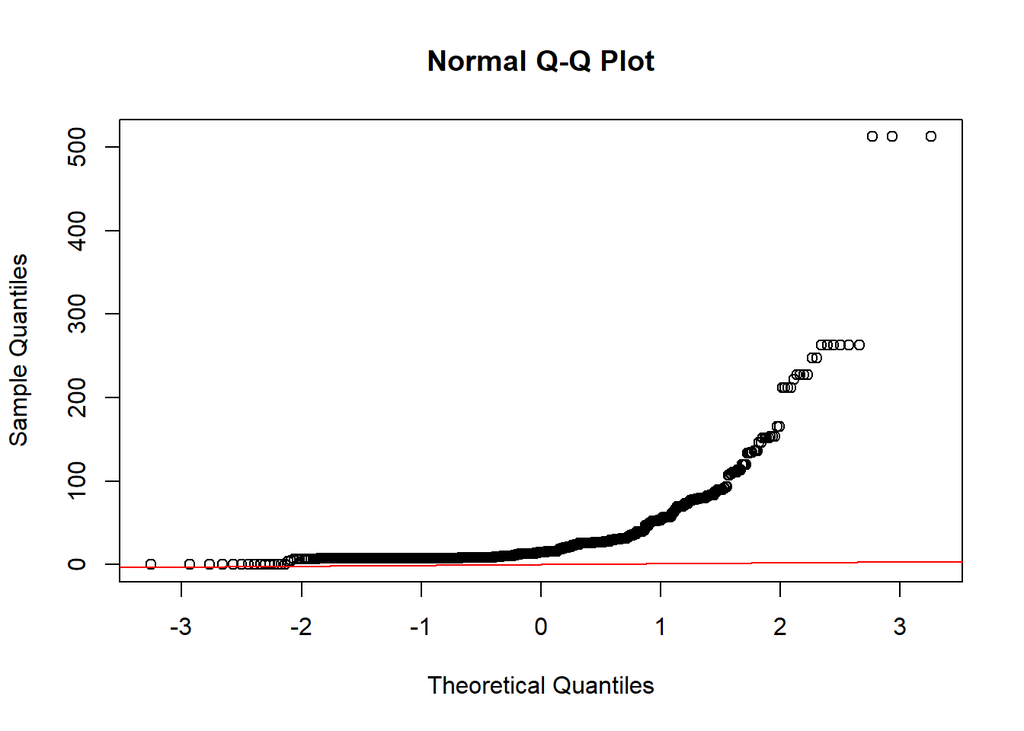

```r
#常態分布的qqplot
qqnorm(titanic$Fare)
abline(0,1,col=2)
```

**Base Graphics in R**

在基礎R繪圖系統下，可以由自己設計各種圖形的每個元素(座標的間距、線的粗細等)，另外，有低階函數、高階函數之分，以高階函數圖形為底，而低階函數可以在上面增加次要資訊或圖形，例如圖例、輔助線。

*以高階函數「plot()」為例*

plot(x, y,

type = “p”, ### types of the plot

pch = , ### the symbol in the plot

main = NULL, ### the title of the plot

lty = , ### the style of a line

lwd = , ### the width of a line

cex = , ### the size of an text

bty=“o”, ### the box around the plot

col = , ### the color of an object

xlim = NULL, ylim = NULL, # the range of an axis

sub = NULL, ### the sub-title of the plot

xlab = NULL, ylab = NULL, # the name of an axis

cex.main = ### the size of the title

)